# Homework 3

CHAO-HUNG

2025-04-28

## Load the necessary packages.

```r
library(ISLR)
library(rpart)
library(tidyverse)
```

```r
library(ggplot2)
library(dplyr)
library(rpart.plot)
library(caret)
```

## Question 1: Poly and Tree Model

Loading the data.

```r
data(Credit)
```

Setting seed and performing a 75-25 train-test split on the data. Then check the data splitting using dim().

```r
set.seed(123)
sample <- sample(
  c(T, F),
  length(Credit$Rating),
  replace = T,
  prob = c(0.75, 0.25)
  )

training <- Credit[sample, ]
testing <- Credit[!sample, ]

dim(training)
```

```
## [1] 303  12
```

```r
dim(testing)
```

```
## [1] 97 12
```

Check for NA first.

```r
sum(is.na(Credit$Rating))
```

```
## [1] 0
```

No NA values.

Now fit a polynomial regression model, using Rating as Y, an orthogonal transformed Income with up to 5 degrees as X, as well as Age, Education, Balance as control variables.

```r
poly.fit1 <- lm(
  Rating ~ poly(Income, 5, raw = F) + Age + Education + Balance,
  data = training
  )
```

```r
summary(poly.fit1)
```

```
##
## Call:
## lm(formula = Rating ~ poly(Income, 5, raw = F) + Age + Education +
##     Balance, data = training)
##
## Residuals:
##     Min      1Q  Median      3Q     Max
## -104.96  -19.14   14.58   25.74   57.35
##
## Coefficients:
##                             Estimate Std. Error t value Pr(>|t|)
## (Intercept)                2.414e+02  1.260e+01  19.161   <2e-16 ***
## poly(Income, 5, raw = F)1  1.291e+03  4.369e+01  29.555   <2e-16 ***
## poly(Income, 5, raw = F)2  3.024e+00  3.877e+01   0.078    0.938
## poly(Income, 5, raw = F)3  4.650e+00  3.875e+01   0.120    0.905
## poly(Income, 5, raw = F)4  5.343e+01  3.888e+01   1.374    0.170
## poly(Income, 5, raw = F)5 -5.087e+01  3.867e+01  -1.316    0.189
## Age                        1.594e-01  1.312e-01   1.215    0.225
## Education                 -6.455e-01  7.171e-01  -0.900    0.369
## Balance                    2.102e-01  5.401e-03  38.911   <2e-16 ***
## ---
## Signif. codes:  0 '***' 0.001 '**' 0.01 '*' 0.05 '.' 0.1 ' ' 1
##
## Residual standard error: 38.65 on 294 degrees of freedom
## Multiple R-squared:  0.9355, Adjusted R-squared:  0.9338
## F-statistic: 533.1 on 8 and 294 DF,  p-value: < 2.2e-16
```

Plotting the result using ggplot().

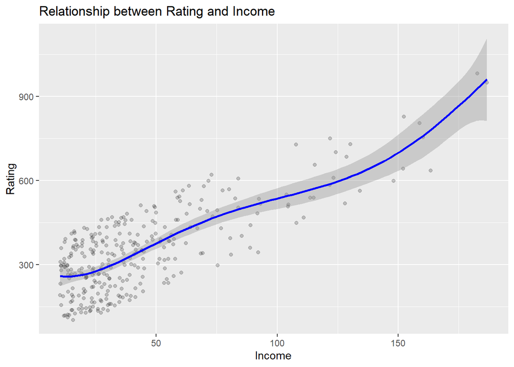

```r
ggplot(training, aes(Income, Rating)) +
  geom_point(alpha = 0.2) +
  labs(title = "Relationship between Rating and Income") +
  stat_smooth(method = lm, formula = y ~ poly(x, 5, raw = F), col = "blue")
```

Fit a tree model using the same features.

```r
tree.fit1 <- rpart(
  Rating ~ Income + Age + Education + Balance,
  data = training
  )

set.seed(123)
```

Take a look at the model output. The threshold value for Income that splits the 6th and 7th nodes is 57.6815, where samples that are smaller than 57.6815 is split to the 6th node, equal to or larger than 57.6815, node 7th.

```r
tree.fit1
```

```
## n= 303
##
## node), split, n, deviance, yval
##       * denotes terminal node
##
##  1) root 303 6809949.00 348.8845
##    2) Balance< 452 150  970858.50 241.4200
##      4) Balance< 98.5 84  260761.00 192.1905
##        8) Income< 42.47 70  106021.80 174.7857 *
##        9) Income>=42.47 14   27510.36 279.2143 *
##      5) Balance>=98.5 66  247420.60 304.0758
##       10) Income< 60.1 57   92384.67 286.6667 *
##       11) Income>=60.1 9   28350.00 414.3333 *
##    3) Balance>=452 153 2408472.00 454.2418
##      6) Income< 57.6815 102  304479.00 387.5686
##       12) Balance< 879 64  109973.80 360.9375 *
##       13) Balance>=879 38   72669.26 432.4211 *
##      7) Income>=57.6815 51  743726.40 587.5882
##       14) Balance< 1418.5 42  199956.10 546.7381
##         28) Income< 115.3215 33   80714.06 522.2424 *
##         29) Income>=115.3215 9   26836.22 636.5556 *
##       15) Balance>=1418.5 9  146611.60 778.2222 *
```

```r
tree.fit1$cptable
```

```
##           CP nsplit rel error    xerror       xstd
## 1 0.50376565      0 1.0000000 1.0064719 0.10772248
## 2 0.19974697      1 0.4962343 0.5180209 0.07002870
## 3 0.06794133      2 0.2964874 0.3479229 0.04179905
## 4 0.05832036      3 0.2285461 0.2824120 0.03803238
## 5 0.01868278      4 0.1702257 0.2158172 0.02487199
## 6 0.01860307      5 0.1515429 0.2048530 0.02190454
## 7 0.01789088      6 0.1329398 0.2032444 0.02188778
## 8 0.01356924      7 0.1150490 0.1855566 0.02082012
## 9 0.01000000      8 0.1014797 0.1691961 0.02021567
```

```r
CPtable <- as.data.frame(tree.fit1$cptable)
CPtable$nsplit[CPtable$"rel error" + CPtable$"xstd" < CPtable$"xerror"][1]
```

```
## [1] 2
```

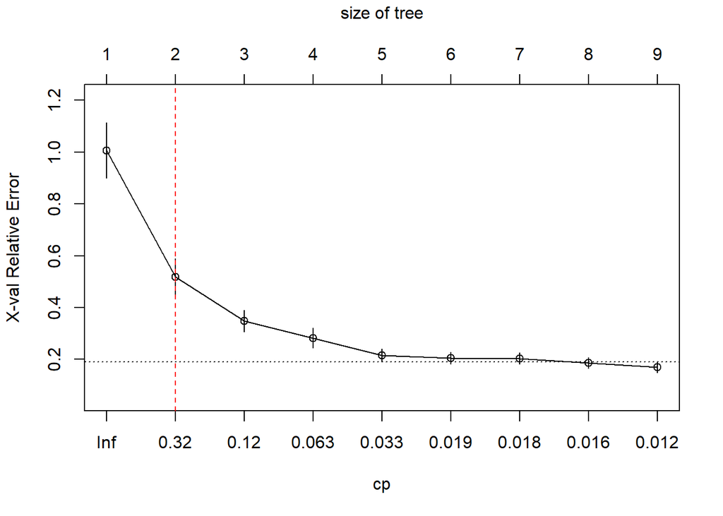

```r
plotcp(tree.fit1)
abline(v = 2, lty = "dashed", col = "red")
```

Make predictions using both models and compare the RMSE and R2.

```r
poly.pred <- poly.fit1 %>% predict(testing)
tree.pred <- tree.fit1 %>% predict(testing)

comparison <- data.frame(
  model = c("Tree Regression", "Polynomial Regression"),
  RMSE = c(RMSE(tree.pred, testing$Rating), RMSE(poly.pred, testing$Rating)),
  R2 = c(R2(tree.pred, testing$Rating), R2(poly.pred, testing$Rating))
  )
```

By this table, I prefer the Poly model, for it has a smaller RMSE and a better model performance based on its R squared value.

```r
library(gridExtra)
```

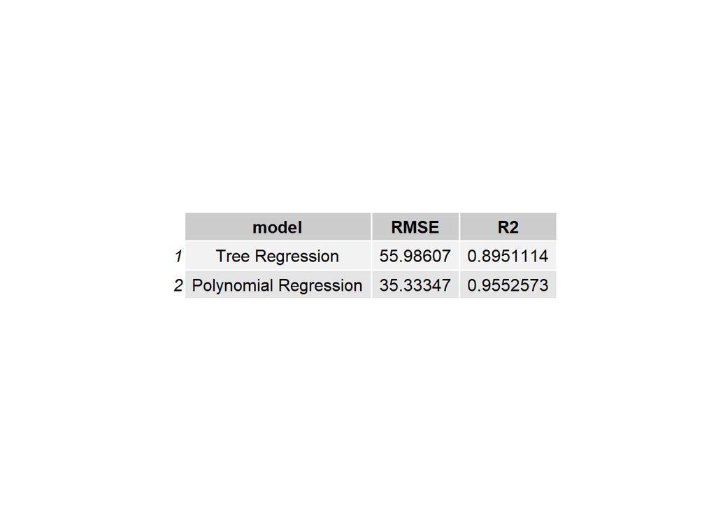

```r
grid.table(comparison)
```